# ASO xdate error metrics

Dominik Schneider

# r<sup>2</sup>

summary of best predictions

| mdlpreds | mean(r2) | median(r2) | sd(r2) |
| --- | --- | --- | --- |
| phv | 0.52 | 0.56 | 0.09 |
| phvfsca | 0.76 | 0.77 | 0.06 |
| phvaso | 0.67 | 0.71 | 0.17 |
| phvasofsca | 0.79 | 0.79 | 0.09 |

## phv

## phvfsca

## phvaso

## phvasofsca

## all model boxplots

# % MAE

summary of best predictions

| mdlpreds | mean(pctmae) | median(pctmae) | sd(pctmae) |
| --- | --- | --- | --- |
| phv | 59.38 | 54.39 | 21.96 |
| phvfsca | 37.14 | 37.61 | 11.93 |
| phvaso | 53.98 | 45.90 | 23.32 |
| phvasofsca | 36.21 | 35.70 | 12.32 |

## phv

## phvfsca

## phvaso

## phvasofsca

## all model boxplots

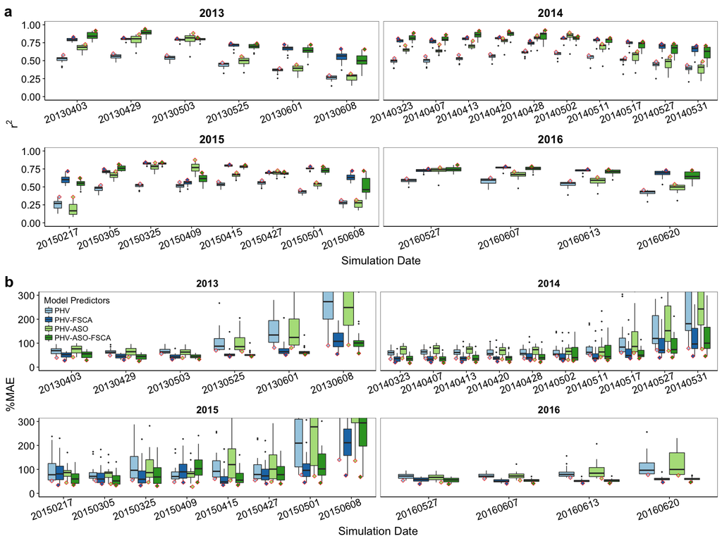

# are the differences in patterns of fsca and swe similar? can fsca patterns be used to pick the date to predict swe?

comparison of maps for each date but leaving out maps from the same year in the comparison

## with mean absolute error

## with mean squared error

more dates are statistically significant with mae so we’ll stick with that.

# compare prediction errors vs basin aggregated snow variables

## compare with best errors

this doesn’t show much. errors go up end of season while mean swe goes down….

## compare with all errors

# compare prediction errors vs fsca pattern differences

## compare with best errors only

again not a very useful plot. errors go up as fsca mae goes down (due to smaller differences when there is less snow cover)

## compare with all errors by date

see “figs/so_many_fscaplots.pdf” for all plots

## Table of significant slopes

| simdte | phv | phvfsca | phvaso | phvasofsca | sep | simdte | phv | phvfsca | phvaso | phvasofsca |
| --- | --- | --- | --- | --- | --- | --- | --- | --- | --- | --- |
| 2013-04-03 | -0.24 | -0.07 | -0.26 | - | \| | 2013-04-03 | 87.25 | - | 113.44 | - |
| 2013-04-29 | -0.24 | - | -0.32 | -0.17 | \| | 2013-04-29 | 73.76 | - | 100.15 | - |
| 2013-05-03 | -0.19 | - | - | - | \| | 2013-05-03 | 60.13 | - | 67.53 | - |
| 2013-05-25 | - | -0.09 | -0.18 | -0.18 | \| | 2013-05-25 | 163.89 | - | 213.94 | - |
| 2013-06-01 | -0.09 | -0.15 | -0.16 | -0.24 | \| | 2013-06-01 | 285.64 | - | 360.21 | - |
| 2013-06-08 | -0.13 | -0.25 | -0.19 | -0.37 | \| | 2013-06-08 | 618.97 | 157.38 | 762.56 | - |
| 2014-03-23 | -0.20 | - | -0.16 | - | \| | 2014-03-23 | 74.09 | -52.27 | 97.27 | -51.56 |
| 2014-04-07 | -0.20 | - | -0.17 | - | \| | 2014-04-07 | 72.32 | -54.53 | 92.60 | -52.38 |
| 2014-04-13 | -0.15 | - | -0.12 | - | \| | 2014-04-13 | 56.55 | -65.95 | 87.28 | -54.56 |
| 2014-04-20 | - | - | - | - | \| | 2014-04-20 | - | - | 93.80 | - |
| 2014-04-28 | - | - | - | -0.20 | \| | 2014-04-28 | - | - | 81.06 | - |
| 2014-05-02 | - | - | - | - | \| | 2014-05-02 | - | - | - | - |
| 2014-05-11 | - | - | - | - | \| | 2014-05-11 | - | - | - | - |
| 2014-05-17 | -0.28 | -0.20 | -0.41 | -0.44 | \| | 2014-05-17 | - | - | - | - |
| 2014-05-27 | -0.29 | -0.28 | -0.42 | -0.49 | \| | 2014-05-27 | 499.44 | - | 670.84 | - |
| 2014-05-31 | -0.27 | -0.30 | -0.37 | -0.54 | \| | 2014-05-31 | 730.34 | - | 935.01 | - |
| 2015-02-17 | -0.54 | -0.33 | -0.50 | - | \| | 2015-02-17 | - | - | - | - |
| 2015-03-05 | -0.29 | -0.11 | -0.32 | -0.17 | \| | 2015-03-05 | - | - | - | - |
| 2015-03-25 | - | - | - | 0.08 | \| | 2015-03-25 | - | - | 292.38 | - |
| 2015-04-09 | -0.16 | -0.19 | -0.22 | -0.24 | \| | 2015-04-09 | - | - | - | - |
| 2015-04-15 | - | - | - | - | \| | 2015-04-15 | 254.24 | - | 358.00 | - |
| 2015-04-27 | -0.28 | -0.10 | -0.21 | - | \| | 2015-04-27 | - | - | - | - |
| 2015-05-01 | - | - | -0.07 | -0.12 | \| | 2015-05-01 | 546.20 | - | 735.10 | - |
| 2015-06-08 | -0.14 | -0.23 | -0.19 | -0.57 | \| | 2015-06-08 | 1298.93 | 377.43 | 1466.82 | 543.49 |
| 2016-05-27 | -0.12 | -0.12 | - | -0.15 | \| | 2016-05-27 | 73.24 | - | 86.43 | - |
| 2016-06-07 | -0.19 | - | - | - | \| | 2016-06-07 | 54.77 | - | 67.80 | - |
| 2016-06-13 | -0.16 | - | -0.18 | -0.16 | \| | 2016-06-13 | 109.99 | - | 158.43 | - |
| 2016-06-20 | -0.11 | -0.15 | -0.17 | -0.30 | \| | 2016-06-20 | 183.25 | 28.92 | 261.79 | 19.85 |

## combine pred error best fit lines by mdlpreds, plot mean +/- se

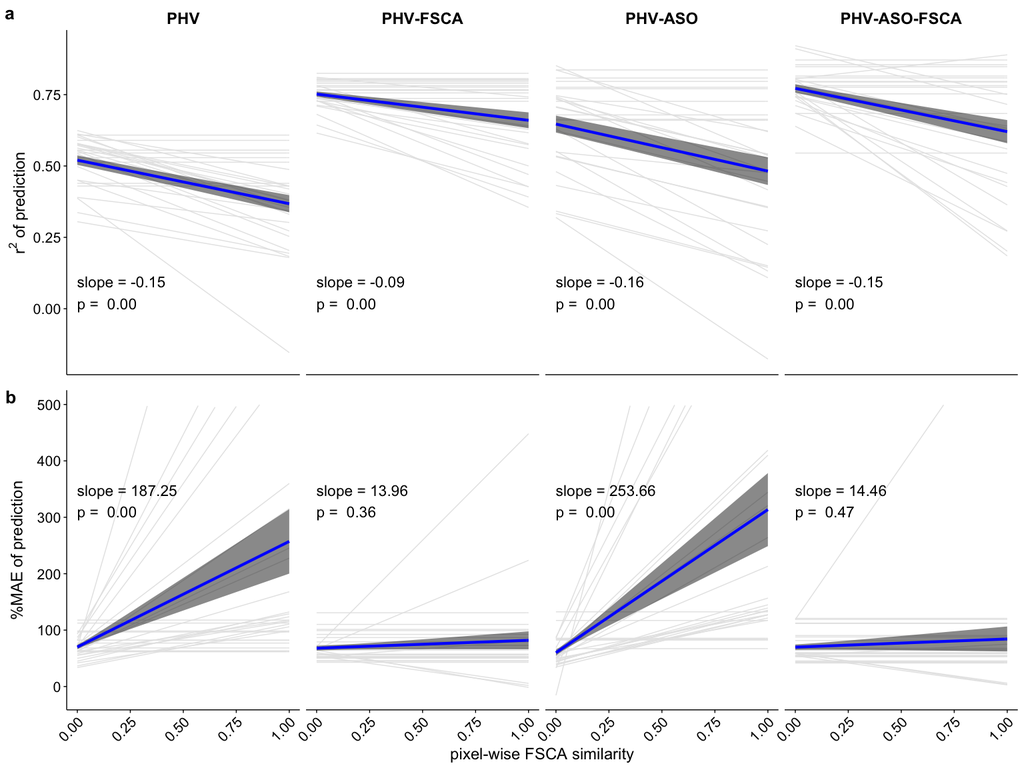

# compare best pred vs lowestfscamae pred

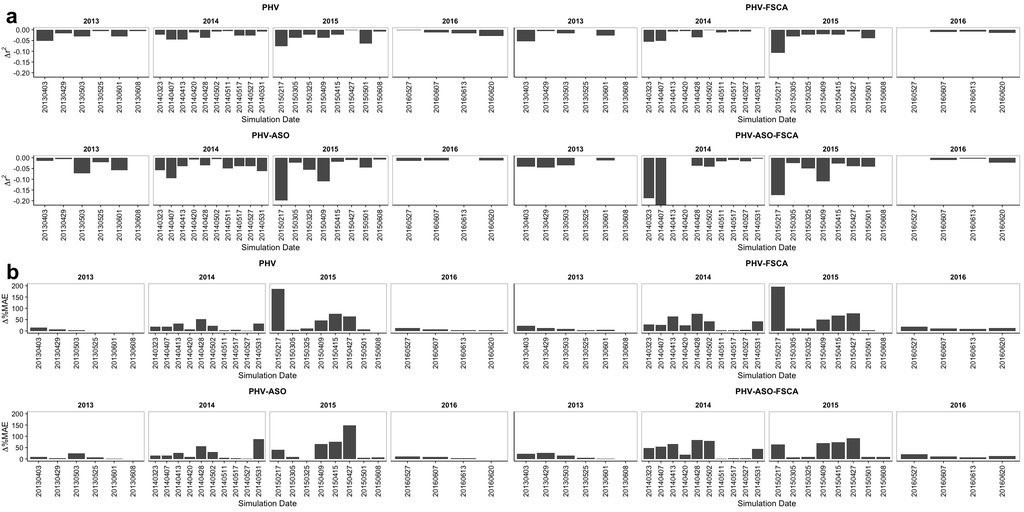

summary stats for differences between r2 of bestpreds and lowestfscamae pred

| mdlpreds | var | mean(val) | sd(val) |
| --- | --- | --- | --- |
| phv | diff | -0.03 | 0.02 |
| phvaso | diff | -0.04 | 0.04 |
| phvasofsca | diff | -0.04 | 0.06 |
| phvfsca | diff | -0.02 | 0.02 |

summary stats of r2 for different modeltypes

| errorvar | mdlpreds | var | mean(val, na.rm = T) | sd(val, na.rm = T) |
| --- | --- | --- | --- | --- |
| r2 | phv | bestpred | 0.52 | 0.09 |
| r2 | phv | lowestfscamae | 0.50 | 0.10 |
| r2 | phvaso | bestpred | 0.67 | 0.17 |
| r2 | phvaso | lowestfscamae | 0.63 | 0.18 |
| r2 | phvasofsca | bestpred | 0.79 | 0.09 |
| r2 | phvasofsca | lowestfscamae | 0.75 | 0.10 |
| r2 | phvfsca | bestpred | 0.76 | 0.06 |
| r2 | phvfsca | lowestfscamae | 0.74 | 0.06 |

summary stats for differences between pctmae of bestpreds and lowestfscamae pred

| mdlpreds | var | mean(val) | sd(val) |
| --- | --- | --- | --- |
| phv | diff | 22.70 | 38.00 |
| phvaso | diff | 23.83 | 34.42 |
| phvasofsca | diff | 30.42 | 29.96 |
| phvfsca | diff | 29.93 | 40.43 |

summary stats for pctmae different modeltypes

| errorvar | mdlpreds | var | mean(val, na.rm = T) | sd(val, na.rm = T) |
| --- | --- | --- | --- | --- |
| pctmae | phv | bestpred | 59.38 | 21.96 |
| pctmae | phv | lowestfscamae | 82.08 | 39.06 |
| pctmae | phvaso | bestpred | 53.98 | 23.32 |
| pctmae | phvaso | lowestfscamae | 77.81 | 37.47 |
| pctmae | phvasofsca | bestpred | 36.21 | 12.32 |
| pctmae | phvasofsca | lowestfscamae | 66.63 | 27.49 |
| pctmae | phvfsca | bestpred | 37.14 | 11.93 |
| pctmae | phvfsca | lowestfscamae | 67.06 | 39.15 |

# swe and fsca difference for best predictions

Again not that useful to look at because prediction error is lowest when fscamae is highest (due to more snow cover earlier in season). Not immediately intuitive until you look at fscamae vs date.